# Assignment 8: Visualization - Making a bar race

*How to do it?*:

- Open the Rmarkdown file of this assignment (link) in Rstudio.
- Right under each **question**, insert a code chunk (you can use the hotkey `Ctrl + Alt + I` to add a code chunk) and code the solution for the question.
- `Knit` the rmarkdown file (hotkey: `Ctrl + Alt + K`) to export an html.
- Publish the html file to your Githiub Page.

*Submission*: Submit the link on Github of the assignment to Canvas

1. Install two packages `gganimate` and `gifski` then restart Rstudio. Using the `Adult Census Income` data, make an animation using `geom_point` and `transition_states`.

```r
setwd("C:/Users/student/Desktop/New folder/math_421")
library(ggplot2)
library(gganimate)
library(dplyr)

df <- read.csv("adult_census_missing.csv")
```

[output not shown]

[output cut: 47 more lines]

[output not shown]

[output not shown]

[output cut: 43 more lines]

[output not shown]

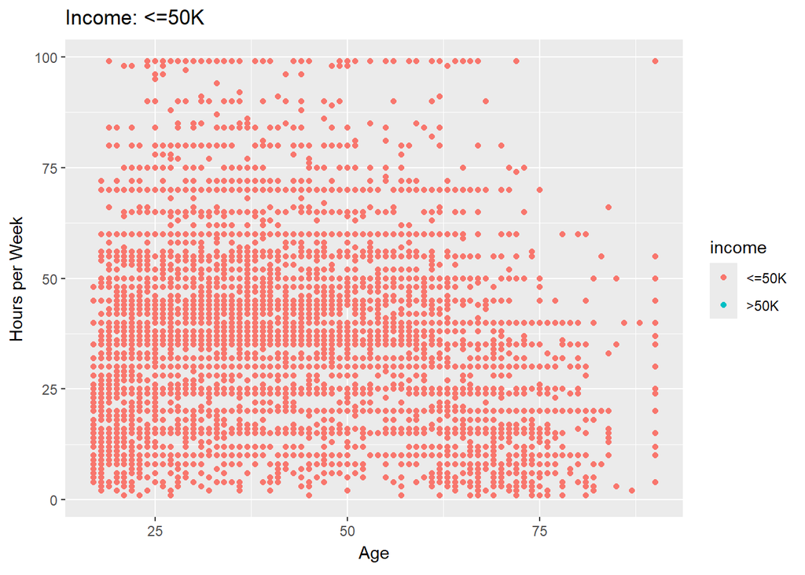

```r
p <- ggplot(df, aes(x = age, y = hours.per.week, color = income)) +
  geom_point() +
  transition_states(income, transition_length = 2, state_length = 1) +
  labs(title = 'Income: {closest_state}', x = 'Age', y = 'Hours per Week')

animate(p, renderer = gifski_renderer())
```

2. Using the `Adult Census Income` data, make an animation using `geom_bar` and `transition_states`.

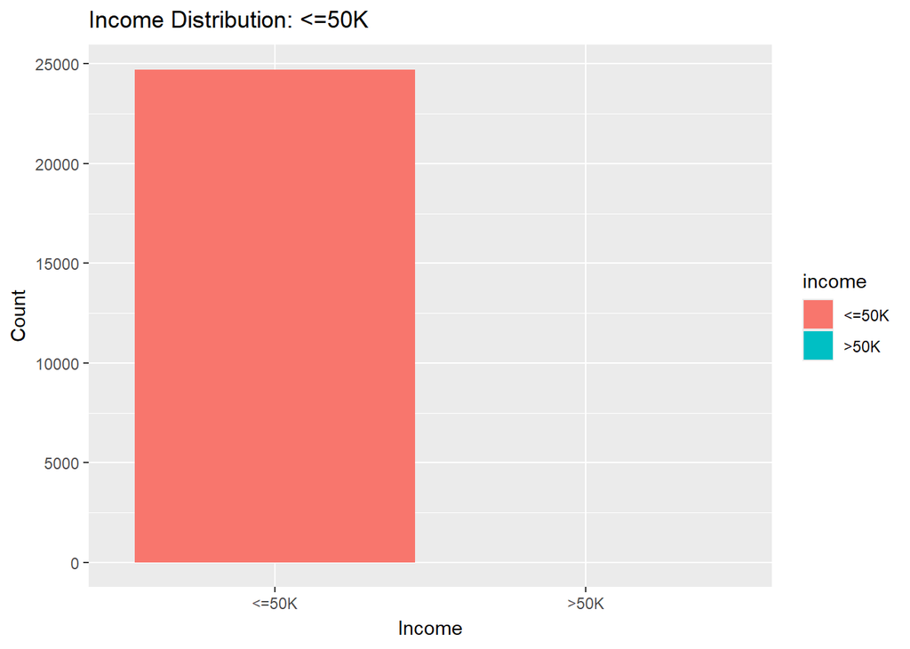

```r
p <- ggplot(df, aes(x = income, fill = income)) +
  geom_bar() +
  transition_states(income, transition_length = 2, state_length = 1) +
  labs(title = 'Income Distribution: {closest_state}', x = 'Income', y = 'Count')

animate(p, renderer = gifski_renderer())
```

3. Use the WHO’s dataset at [this link](https://covid19.who.int/WHO-COVID-19-global-data.csv). Make a top-10 bar race by months between countries on the number of deaths by Covid 19 in 2021.

```r
library(readr)
```

```r
library(dplyr)
library(ggplot2)
library(gganimate)
setwd('C:/Users/student/Desktop/New folder/math_421')

who_data <- read_csv("WHO-COVID-19-global-data.csv")
```

```r
who_data <- who_data %>%
  mutate(Date_reported = as.Date(Date_reported, format = "%Y-%m-%d")) %>%
  filter(format(Date_reported, "%Y") == "2021") %>%
  mutate(month = format(Date_reported, "%Y-%m")) %>%
  group_by(month, Country) %>%
  summarize(deaths = sum(New_deaths, na.rm = TRUE)) %>%
  ungroup() %>%
  arrange(desc(deaths)) %>%
  group_by(month) %>%
  mutate(rank = row_number(-deaths)) %>%
  filter(rank <= 10)
```

```r
p <- ggplot(who_data, aes(x = reorder(Country, -deaths), y = deaths, fill = Country)) +
  geom_bar(stat = "identity") +
  coord_flip() +
  labs(
    title = "Top 10 Countries by COVID-19 Deaths in {closest_state}",
    x = "Country",
    y = "Deaths"
  ) +
  theme_minimal() +
  transition_states(
    states = month,
    transition_length = 2,
    state_length = 1
  ) +
  ease_aes('cubic-in-out')
```

[figure not shown]

```r
animate(p, renderer = gifski_renderer("who_bar_race.gif"))
```

4. Make a bar race using a dataset of your own interest. You may use the dataset that we use in class (https://covidtracking.com/data/download/all-states-history.csv) but you should make a different bar racev from ones in the slides.

```r
covid_data <- read_csv("all-states-history.csv")
covid_data <- covid_data %>%
  mutate(date = as.Date(date)) %>%
  filter(date >= as.Date("2021-01-01") & date <= as.Date("2021-12-31")) %>%
  group_by(date, state) %>%
  summarize(deaths = sum(deathIncrease, na.rm = TRUE)) %>%
  arrange(desc(deaths)) %>%
  group_by(date) %>%
  top_n(10, deaths)
```

```r
p <- ggplot(covid_data, aes(x = reorder(state, -deaths), y = deaths, fill = state)) +
  geom_bar(stat = "identity") +
  coord_flip() +
  transition_states(as.factor(date), transition_length = 2, state_length = 1) +
  labs(
    title = "Top 10 States by COVID-19 Deaths: {closest_state}",
    x = "State",
    y = "Deaths"
  ) +
  theme_minimal()
```

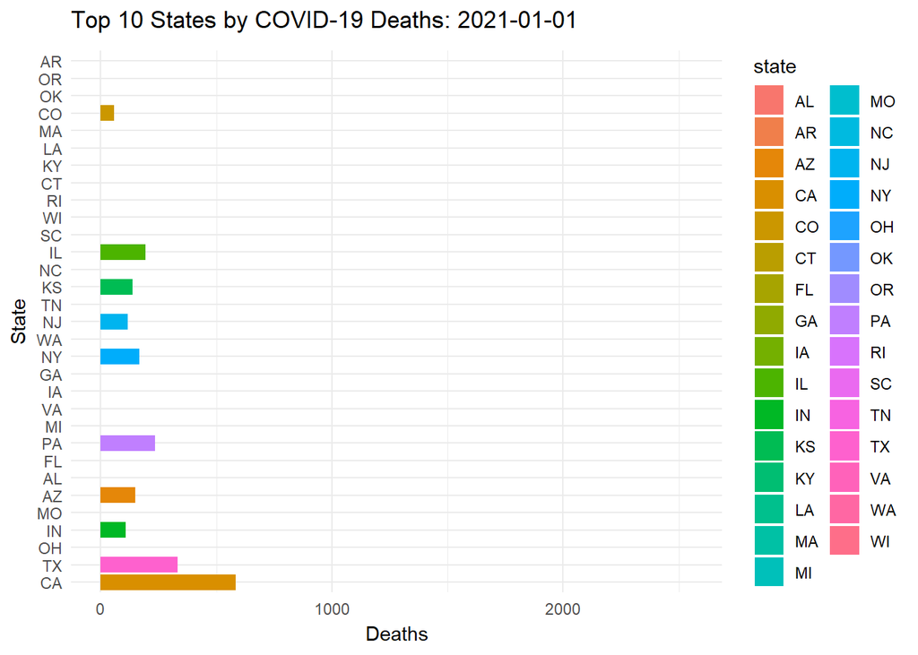

```r
animate(p, renderer = gifski_renderer("covid_state_bar_race.gif"))
```